# Laboratory6

# Introduction

This lab covers much to do with the practicalities of continuous random variables and their distributions. How do you calculate probabilities etc.

However, we shall also look at some of the items covered in the book that you might miss as inconsequential.

Because densities have certain properties,

> 1. $f(y)\ge 0$
> 2. $\int_{-\infty}^{+\infty}f(y)dy =1$
> 3. $P(a< Y<b)=\int_{a}^{b}f(y)dy = F(b)-F(a)$

a number of implied and consequential functions result.

## Example

The gamma function $\Gamma(t)$, is defined from the Gamma density, $Y\sim Gamma(\alpha, \beta)$.

$$\Gamma(t) = \int_0^{\infty}y^{t-1}e^{-y}dy$$
It so happens that this function has many important applications and properties not least of which is that it generalizes the notion of a factorial.

If $t$ is a positive integer then:

$$\Gamma(t) = (t-1)!$$

## R’s gamma function

You can calculate the gamma for any $t\in \Re^{+}$

```r
gamma(5.678)
ws#> [1] 69.94505
gamma(5) == factorial(4)
ws#> [1] TRUE
```

# Objectives

In this lab you will learn how to:

> 1. Plot densities.
> 2. Make areas under the curve.
> 3. Calculate probabilities.
> 4. Create a function that calculates and displays areas
> 5. Add the above function to a package

You can learn more about R in relation to densities and plots here https://ademos.people.uic.edu/index.html

# Using and understanding R density functions

There are 7 continuous distributions we will need to understand and use well.

For each of these distributions there are 4 important functions. Below are the four in the case of a Normal distribution

```r
dnorm() # make a density plot (the height of the density f(x))
pnorm() # the lower tail probability P(X<=x)
qnorm() # The x that corresponds to a lower tail area
rnorm() # A random sample from the distribution
```

The 7 densities for the 7 distributions take the following form

```r
dunif()
dnorm()
dgamma()
dchisq()
dexp()
dweibull()
dbeta()
```

# Solving statistical and probabilistic problems

The difficulties students face with the 7 continuous distribtions and their associated densities relates to:

> 1. Discovery of the correct distribution for a particular problem.
> 2. Choosing which of the four functions to use:
> - d-stem
> - p-stem
> - q-stem
> - r-stem
> 3. Re-parameterizing in order to use the software

The last difficulty comes about because parameterization is not unique. This is the case for discrete distributions also. You learn a particular formualic system (density and 2 moments each expressed in terms of the parameters) for say the `Weibull` and then discover your favorite statistical workspace uses a different formula.

## MS Weibull

$$f(y) = \frac{\alpha}{\beta}y^{\alpha-1}e^{-y^{\alpha}/\beta}\; 0\le y < \infty;\; \alpha>0;\; \beta>0$$

## R Weibull

$$f(x) = \frac{a}{b}\left(\frac{x}{b}\right)^{a-1}e^{-(\frac{x}{b})^a}\; 0\le X < \infty ; a>0; b>0$$

You will need to take the MS formulation and transform to R – that is use the following transformation

$$a= \alpha$$
$$b^a = \beta$$
So that if you know $\alpha$ and $\beta$ you can find $a$ and $b$ and hence use R. These problems will not go away – you must get used to adapting to the software you have regardless of the theoretical formulation you are used to.

# Examples

## Example 1: The uniform density

Suppose $Y \sim Unif(2,6)$ find the probability $P(Y > 4)$.

### Reparameterize

None

### Plot $X$ in R

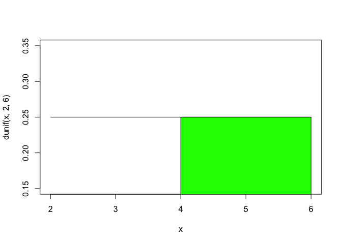

```r
curve(dunif(x, 2,6), xlim=c(2,6))

xcurve <- seq(4,6, length = 1000)
ycurve <- dunif(xcurve, 2, 6)
polygon(x = c(4,xcurve,6), y=c(0,ycurve,0), col = "green")
```

Solution: $P(Y>4)=1-P(Y\le 4)=$ `1-punif(4,2,6)=` 0.5

## Example 2: The normal density

Suppose $Y\sim N(\mu = 10, \sigma = 5)$ find the probability $P(3 \le Y < 8)$

### Reparameterize

None

### Plot $X$ in R

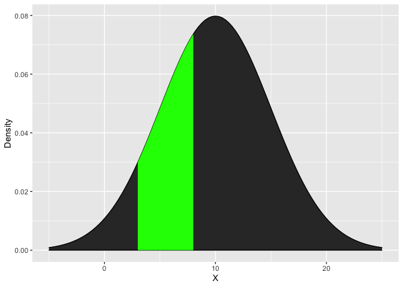

```r
library(ggplot2)

normargs <- list(mean = 10, sd = 5)

n <- ggplot(data.frame(x = c(-5,25)), aes(x)) +
  stat_function(fun = dnorm, args = normargs , geom = "area", col = "black")


n <- n + stat_function(fun = dnorm, args = normargs, geom = "area", fill = "green", alpha = 2,xlim = c(3,8))

n <- n + xlab("X") + ylab("Density")
n
```

Solution:

$P(3\le Y < 8) = P(Y\le 8)-P(Y\le 3)=$ `pnorm(8,10,5)-pnorm(3,10,5)=` 0.2638216

## Example 3: The gamma density

Suppose that $Y\sim Gamma(\alpha =4, \beta = 4)$ find the probability $P(Y\le 6)$

### Reparameterize

`shape` = $\alpha$

`scale` = $\beta$

### Plot $X$ in R

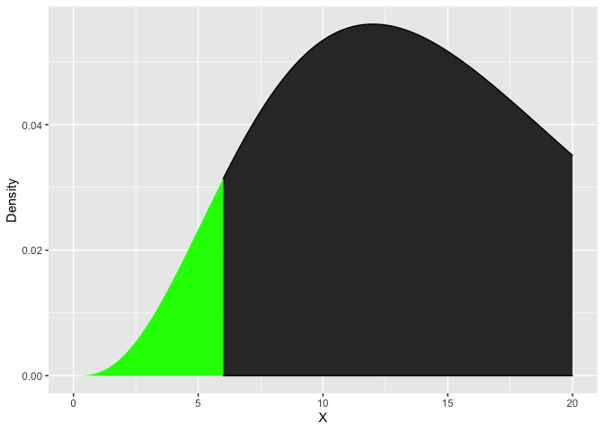

```r
gamargs = list(shape=4, scale=4)
g <- ggplot(data.frame(x=c(6,20)), aes(x)) +
  stat_function(fun = dgamma, args = gamargs , geom = "area", col = "black")


g <- g + stat_function(fun = dgamma, args = gamargs, geom = "area", fill = "green", alpha = 2,xlim = c(0,6))

g <- g + xlab("X") + ylab("Density")
g
```

Solution: $P(Y\le 6)=$`pgamma(6,shape = 4,scale = 4)=` 0.0656425

## Example 4: The Chi-square density

Suppose $Y\sim Chisq(\nu=5)$ find the probability $P(Y > 6)$

### Reparameterize

$df = \nu$

### Plot $X$ in R

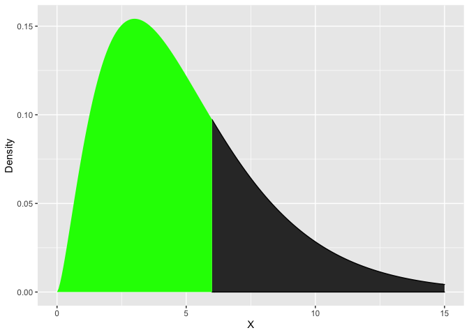

```r
chiargs = list(df = 5)
ch <- ggplot(data.frame(x = c(6,15)), aes(x)) +
  stat_function(fun = dchisq, args = chiargs , geom = "area", col = "black")


ch <- ch + stat_function(fun = dchisq, args = chiargs, geom = "area", fill = "green", alpha = 2,xlim = c(0,6))

ch <- ch + xlab("X") + ylab("Density")
ch
```

Solution: $P(Y>6)=1-P(Y\le 6)=$ `1-pchisq(6,df=5)=` 0.3062189

## Example 5: The exponential density

Suppose $Y \sim Exp(\beta = 4)$ find the probability $P(3\le Y\le 6)$

### Reparameterize

$rate = 1/\beta$

### Now plot using $X$ in R

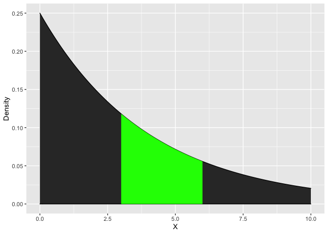

```r
expargs = list(rate = 1/4)
e <- ggplot(data.frame(x = c(0,10)), aes(x)) +
  stat_function(fun = dexp, args = expargs , geom = "area", col = "black")


e <- e + stat_function(fun = dexp, args = expargs, geom = "area", fill = "green", alpha = 2,xlim = c(3,6))

e <- e + xlab("X") + ylab("Density")
e
```

Solution: $P(3\le Y\le 6)=P(Y\le 6)-P(Y\le 3)=$ `pexp(6,1/4)-pexp(3,1/4)=` 0.2492364

## Example 6: The Weibull density

Please note that the parameters are more complex here – see the discussion in the sections above. You must look at the densities in MS and R.

Suppose $Y\sim Weibull(\alpha = 3, \beta =4)$ find the probability $P(Y\le 0.5)$

### Reparameterize

$shape = \alpha$

$scale = \beta^{1/a}$

### Now plot using $X$ in R

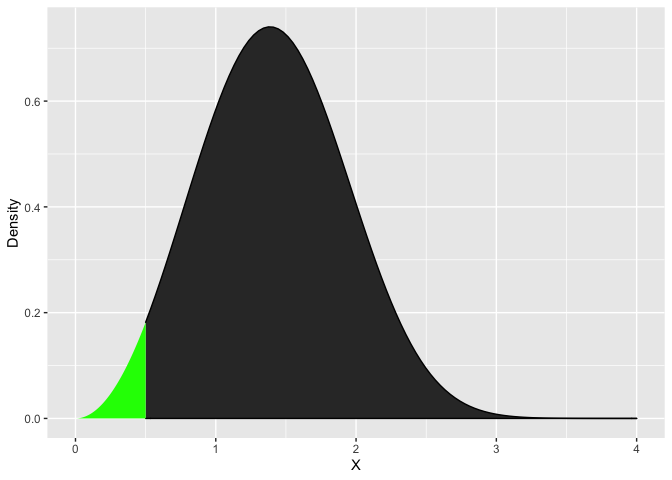

```r
weargs = list(shape = 3,scale =(4)^(1/3) )
w <- ggplot(data.frame(x = c(0.5,4)), aes(x)) +
  stat_function(fun = dweibull, args = weargs , geom = "area", col = "black")


w <- w + stat_function(fun = dweibull, args = weargs, geom = "area", fill = "green", alpha = 2,xlim = c(0,0.5))

w <- w + xlab("X") + ylab("Density")
w
```

Solution: $P(Y\le 0.5)=$ `pweibull(0.5,shape = 3, scale=(4)^(1/3))=` 0.0307668

## Example 7: The Beta density

Suppose that $Y\sim Beta(\alpha = 3,\beta = 5)$ find the probability $P(0.2\le Y\le 0.5)$

### Reparameterize

`shape1=`$\alpha$

`shape2` = $\beta$

### Now plot using $X$ in R

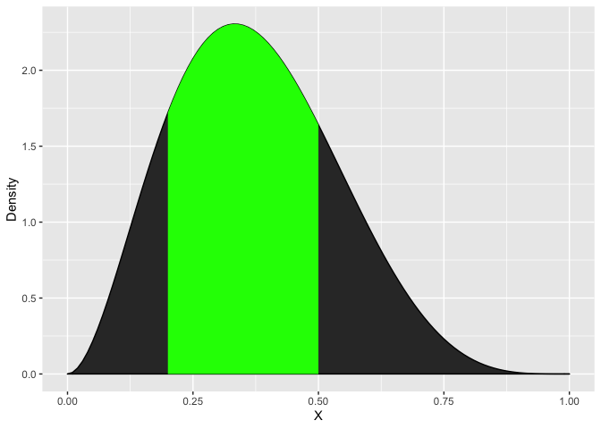

```r
bargs <- list(shape1 = 3, shape2 = 5 )

b <- ggplot(data.frame(x = c(0,1)), aes(x )) +
  stat_function(fun = dbeta, args = bargs , geom = "area", col = "black")


b <- b + stat_function(fun = dbeta, args = bargs, geom = "area", fill = "green", alpha = 2,xlim = c(0.2,0.5))

b <- b + xlab("X") + ylab("Density")
b
```

Solution:

$P(0.2\le Y\le 0.5)=P(Y\le 0.5)-P(Y\le0.2)=$`pbeta(0.5,3,5)-pbeta(0.2,3,5)=` 0.6254055

# Functions

After reviewing examples 1-7 you can see that a lot of the code was repeated and that only a few things changed from example to example (the unif was a little different because I used base R). Can we make a function to expedite the calculation and save time and space?

I will give you edition 1 of the function and then you can improve it.

```r
ggareai2r <- function(gargs,xrange,xarea,dfun){


g <- ggplot(data.frame(x = xrange), aes(x)) +
  stat_function(fun = dfun, args = gargs , geom = "area", col = "black")


g <- g + stat_function(fun = dfun, args = gargs, geom = "area", fill = "green", alpha = 2,xlim = xarea)

g <- g + xlab("X") + ylab("Density")

print(g)

}
```

## Try it out

Lets make a Beta density $Beta(7,9)$ with area over the interval `(0.4,0.8)`.

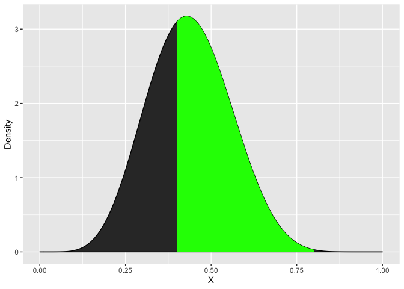

```r
ggareai2r(gargs=list(shape1= 7,shape2=9),xrange = c(0,1),xarea=c(0.4,0.8),dfun = "dbeta")
```

## Uniform density

Say $Y\sim Unif(3,10)$ and we want the are above `(4,8)`

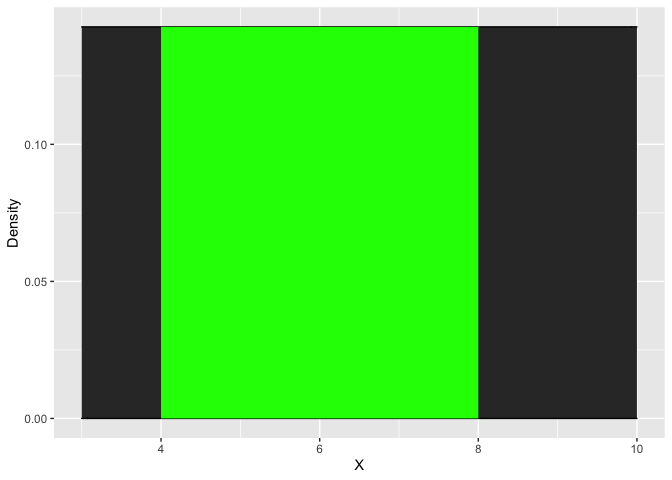

```r
ggareai2r(gargs=list(min = 3, max = 10),xrange = c(3,10), xarea = c(4,8),dfun = "dunif")
```

The rest of the lab involves other important tasks and activities one of which pertains to the addition of a function to an R package.

# Finally

Please donload and install the following into their appropriate directories MATH4753Laboratory6.docx, change-parameters.html, lab6.R

Now you can start on the tasks as given in the word file.